[GitHub](https://github.com/agate-model/Agate.jl)[](https://github.com/agate-model/Agate.jl/blob/main/examples/named_plankton_groups.jl)

# Comparing phytoplankton light strategies

Plankton are highly diverse, and representing some of this diversity can be important in ecosystem models. One important axis of variation is adaptation to the light environment, which can differ both between and within species. High- and low-light-adapted *Prochlorococcus* ecotypes provide a well-known example of this ecological differentiation.

Here, we use this idea to construct two idealized phytoplankton functional types with the same cell size but different light-response traits. This allows us to isolate the effect of light adaptation and explore how the two functional types respond under low- and high-light conditions.

The `low_light` type has a lower maximum growth rate but a steeper initial light-response slope than `high_light`. We place the same community in two otherwise identical box models, differing only in photosynthetically active radiation (PAR), and compare which type is more competitive in each light environment.

## Loading dependencies

The example uses Agate.jl, Oceananigans.jl, and OceanBioME.jl for the ecosystem simulations. CairoMakie.jl is used for plotting.

```julia
using Agate
using Agate.Introspection: tracer_names
using Agate.Library.Light
using OceanBioME
using OceanBioME: Biogeochemistry
using Oceananigans
using Oceananigans.Units
using CairoMakie
```

## Ecosystem model

Named groups are defined separately for the phytoplankton and zooplankton roles. Both phytoplankton types use the same diameter so their different behavior comes from the trait overrides rather than from size-dependent defaults.

```julia
size_structure = (;
    phytoplankton=(high_light=[0.7], low_light=[0.7]),
    zooplankton=(grazer=[30.0],),
)
```

The two phytoplankton types are given a simple growth trade-off. `high_light` has the larger maximum growth rate, while `low_light` has the larger `alpha`, the initial slope of the Smith photosynthesis-irradiance curve. The parameter values are illustrative and chosen so that `low_light` grows faster at low PAR and `high_light` grows faster at high PAR.

```julia
parameters = (;
    maximum_growth_rate=(high_light_1=2.0 / day, low_light_1=1.4 / day),
    alpha=(high_light_1=0.15 / day, low_light_1=0.30 / day),
)

bgc = Agate.Models.NiPiZD.construct(; size_structure, parameters)
```

The named groups are realized as deterministic tracer names.

```julia
println(tracer_names(bgc))
```

```
[:N, :D, :grazer_1, :high_light_1, :low_light_1]
```

## Light treatments

We compare a low-light treatment at PAR = 5 with a high-light treatment at PAR = 100. Every other part of the ecosystem setup is shared between the two simulations.

```julia
low_PAR = 5.0
high_PAR = 100.0
```

```
100.0
```

## Run the box models

```julia
function run_light_treatment(bgc, PAR, filename)
    grid = BoxModelGrid()
    constant_PAR = t -> PAR
    light_attenuation = FunctionFieldPAR(; grid, PAR_f=constant_PAR)
    bgc_model = Biogeochemistry(bgc; light_attenuation)
    full_model = BoxModel(; biogeochemistry=bgc_model)

    set!(
        full_model;
        N=20.0,
        D=0.0,
        grazer_1=0.0,
        high_light_1=0.01,
        low_light_1=0.01,
    )

    simulation = Simulation(full_model; Δt=60minutes, stop_time=3days)

    simulation.output_writers[:fields] = JLD2Writer(
        full_model,
        full_model.fields;
        filename,
        schedule=TimeInterval(1hour),
        overwrite_existing=true,
    )

    run!(simulation)

    return filename
end

low_filename = run_light_treatment(bgc, low_PAR, "named_groups_low_light.jld2")
high_filename = run_light_treatment(bgc, high_PAR, "named_groups_high_light.jld2")
```

[output not shown]

## Load the output time series

```julia
function phytoplankton_timeseries(filename)
    high_light = FieldTimeSeries(filename, "high_light_1")[1, 1, 1, :]
    low_light = FieldTimeSeries(filename, "low_light_1")[1, 1, 1, :]
    times = FieldTimeSeries(filename, "high_light_1").times
    return (; times, high_light, low_light)
end

low = phytoplankton_timeseries(low_filename)
high = phytoplankton_timeseries(high_filename)
```

## Compare the light treatments

Both simulations start with equal phytoplankton biomass. Under low PAR, the steeper initial light-response slope favors `low_light`. Under high PAR, the larger maximum growth rate favors `high_light`.

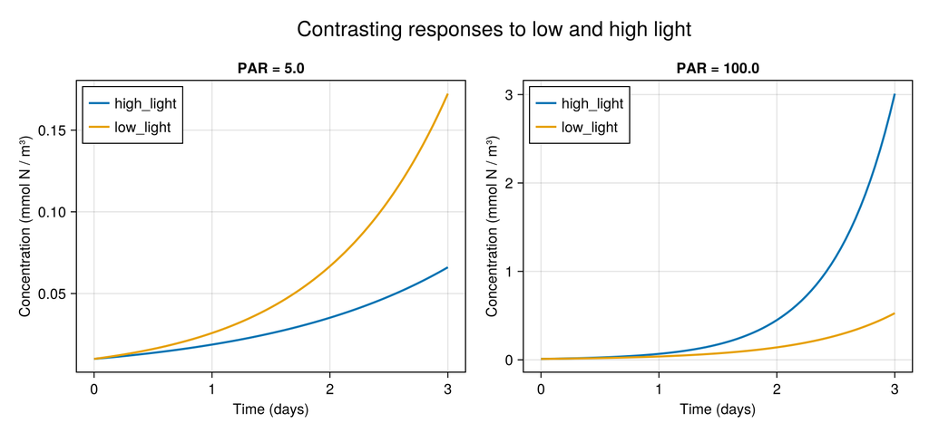

```julia
fig = Figure(; size=(900, 420), fontsize=14)

for (column, treatment, PAR) in ((1, low, low_PAR), (2, high, high_PAR))
    ax = Axis(
        fig[1, column];
        xlabel="Time (days)",
        ylabel="Concentration (mmol N / m³)",
        title="PAR = $(PAR)",
    )

    lines!(
        ax,
        treatment.times / day,
        treatment.high_light;
        label="high_light",
        linewidth=2,
    )
    lines!(
        ax,
        treatment.times / day,
        treatment.low_light;
        label="low_light",
        linewidth=2,
    )
    axislegend(ax; position=:lt)
end

Label(fig[0, 1:2], "Contrasting responses to low and high light"; fontsize=20)

save("named_plankton_groups.png", fig; px_per_unit=1)

fig
```

*This page was generated using Literate.jl.*